# Aproximações para a duração média de passeios aleatórios

Autores

Eduardo Yukio Garrafa Ishihara

Gustavo Silva Garone

Elisabeti Kira

Data de Publicação

11 de dezembro de 2025

Resumo

Inspirados na física, propusemos aproximações para a duração de passeios aleatórios diversos, em especial, os de difícil derivação analítica. Para avaliar as aproximações, utilizamos simulações de Monte Carlo na linguagem Julia. Analisamos o desempenho desta linguagem comparando-a com a linguagem Python. Com modelos (passeios) mais sofisticados, utilizamos recursos computacionais para solução de sistemas lineares na construção de novas aproximações, descrevendo o uso de paralelismo e de outras ferramentas. Exibimos e analisamos os resultados obtidos, assim como os algoritmos utilizados.

Palavras-chave

Passeio Aleatório, Monte Carlo, Estimação

# Introdução

Neste artigo, estudaremos a duração de passeios aleatórios e suas aproximações. Temos como objetivo descrever modelos de passeios como a “Ruína do Jogador” de Pascal, discutido em EDWARDS (1983), generalizando-o para múltiplas dimensões. Abordaremos técnicas analíticas, computacionais e de estimativas para a duração esperada destes passeios.

Começaremos por definir o modelo que será utilizado para descrever os passeios aleatórios, acompanhado de exemplo. Então, apresentaremos o estimador descrito por ISHIHARA (2025), e partiremos para sua avaliação. Primeiramente, compará-lo-emos com resultados probabilísticos estabelecidos na área. Quando avançarmos para passeios em que resultados analíticos não são factíveis, iniciaremos a comparação do estimador com simulações de Monte Carlo.

Descrevemos e justificamos pela literatura a adoção da linguagem de programação *Julia*, essencial para possibilitar a execução eficiente de simulações computacionalmente intensivas em passeios mais complexos.

Em dimensões maiores, forneceremos, até onde é computacionalmente possível, resultados exatos para a duração esperada de passeios aleatórios. Para obter esses resultados, utilizaremos métodos para solução de sistemas lineares extensos simbólicos e empregaremos técnicas de computação paralela, que serão brevemente discutidas.

Este artigo priorizará a descrição do aspecto computacional dessa pesquisa. Leitores são encorajados a consultar a referência ISHIHARA (2025) para uma descrição mais detalhada da construção matemática do estimador e do modelo utilizado.

# Modelando passeios aleatórios

## Modelo

**Definição 1** Considere que o jogador $A$ começa com uma fortuna inicial com um total $\$N$ em jogo, $\$a$, $0 \leq a \leq N$, fornecendo um espaço de estados $\{0, 1, \dots, a, \dots, N\}$. Cada rodada produz um resultado aleatório independente $X_i$, $i=1,2,\dots$, representando o ganho ou perda naquela etapa. Isso será chamado de variável “regra”. Após $n$ rodadas, a fortuna do jogador $A$ é dada por

$$S_n = a + \sum_{i=1}^n X_i.$$

A **duração do jogo** é o primeiro tempo $n$ tal que $S_n \leq 0$ (ruína) ou $S_n \geq N$ (vitória). É denotada por $\tau_{X, a, N}$, a regra de parada.

Ao indexarmos $X$ na posição atual do passeio, $X_{n} := X_{S_n}$, podemos estender esse modelo para passeios em meio não homogêneo: definimos $\pmb{R} = \{X_1, \dots, X_N\}$ e $\tau_{\pmb{R}, a, N}$.

*Comentário 1*. Neste artigo, não trataremos de passeios em meio não homogêneo no tempo, mas podemos, se preciso, estender esse modelo para incluir essa característica.

Para ajudar no entendimento deste modelo, oferecemos um exemplo:

Seja $a = 50$ e $N = 100$. A variável regra do jogo é dada por

$$X = \begin{cases}
-1, & \mathbb{P}(X = -1) = 0.4, \\
+1, & \mathbb{P}(X = +1) = 0.6.
\end{cases}$$

Nota-se que a regra é a mesma para todo estado $S_n$ enquanto o jogo durar, ou seja, o passeio está homogêneo no espaço e tempo.

Após $5$ jogadas, o jogo tomou o seguinte percurso:
$$\pmb{x} = \{x_1, x_2, x_3, x_4, x_5\} = \{1, -1, 1, 1, -1\}.$$

temos então que a posição (fortuna) atual do jogador é
$$S_5 = 50 + (1 - 1 + 1 + 1 -1) = 51.$$

## Jogos unitários e não unitários

Definimos um jogo como **unitário** se a variável regra $X$ assume apenas valores inteiros unitários, ou seja, $X: \Omega \rightarrow \{-1, +1\}$. Caso contrário, o jogo é dito **não unitário**. No Exemplo 1, o jogo é unitário.

Essa distinção faz-se importante, uma vez que, como apresentaremos na próxima seção, a abordagem analítica para determinar a duração esperada do jogo difere entre jogos unitários e não unitários. De fato, em jogos não unitários, a determinação analítica de $\mathbb{E}(\tau_{X, a, N})$ pode ser muito mais complexa, ou até mesmo inviável.

## Abordagem analítica para determinar $\mathbb{E}(\tau_{X, a, N})$

Estamos interessados na duração esperada do jogo, ou seja, queremos encontrar $\mathbb{E}(\tau_{X, a, N})$. Para jogos unitários, podemos calcular essa esperança por simples condicionamento, como descrito em STERN (1975).

Com o uso de equações de diferenças finitas, podemos obter esses mesmos resultados de forma mais elegante, como feito por ANDĚL; HUDECOVÁ (2012). Desses métodos, obtemos a seguinte expressão para a duração esperada desses jogos:

$$\mathbb{E}(\tau_{X, a, N}) = \begin{cases}
a(N - a), & \mathbb{E}(X) = 0, \\
\frac{a}{q-p}-\frac{N}{q-p} \left( \frac{1- \left( \frac{q}{p} \right)^a}
{1- \left( \frac{q}{p} \right)^N}\right), & \mathbb{E}(X) \neq 0.
\end{cases}.
\tag{1}$$

em que $p = \mathbb{P}(X = +1)$ e $q = \mathbb{P}(X = -1) = 1 - p$.

Com esse mesmo método, é possível determinar o tempo esperado para alguns outros jogos. Contudo, como descrito por ISHIHARA (2025), a complexidade de resolução do sistema de EDFs cresce exponencialmente. Essa limitação motivou a criação de um estimador para $\mathbb{E}(\tau_{X, a, N})$.

# Aproximando durações de passeios aleatórios

Uma pergunta natural quando se discute aproximações é quanto a sua utilidade. Se possível, é mais desejável utilizar resultados obtidos analiticamente, como, no exemplo da “Ruína do Jogador” clássica, os apresentados na Seção 2.3.

Ainda assim, a simulação também traz desvantagens para além da perda de precisão e de interpretabilidade. Por exemplo, como abordado em RITTER et al. (2011), um número considerável de simulações é necessário para garantir acurácia dos dados e estabilidade. Diante disso, vê-se justificável a busca de estimadores eficientes para a duração esperada de passeios aleatórios diversos.

## Um estimador heurístico

Baseando-se na mecânica clássica, ISHIHARA (2025) propôs um estimador para passeios não unitários em meio homogêneo:

**Definição 2** Seja um jogo definido conforme a Definição 1, com variável regra $X$ tal que $\mathbb{E}(X) \neq 0$, valores $a$ e $N$. O estimador proposto para a duração esperada desse jogo é dado por:

$$\hat{\mathbb{E}}(\tau_{X, a N}) = \begin{cases}
\frac{N-a}{\mathbb{E}(X)}, & \mathbb{E}(X) > 0, \\
\left \lvert \frac{a}{\mathbb{E}(X)} \right \rvert, & \mathbb{E}(X) < 0.
\end{cases}$$

Partimos para testá-lo em outros casos unitários. Dos nossos resultados, obtemos, fixada a fortuna inicial $a=50$ e total $N$, e variando a probabilidade de ganho $p$:

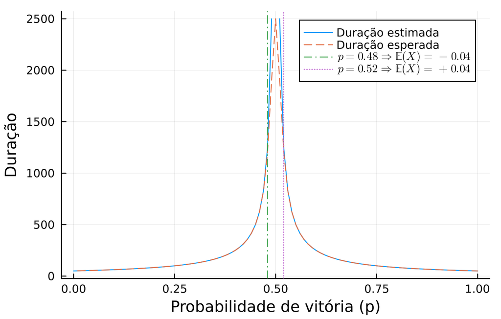

Figura 1: Comparação entre estimador simples e duração esperado em jogos unitários para $a = 50$ e $N = 100$ em função de $p$.

Fonte: Aproximações para a duração média de passeios aleatórios

Notamos que o estimador apresenta bom corpotamento nessa classe de jogos. Uma inadequação de seu uso existe para casos em que $\mathbb{E}(X)$ se aproxima de $0$, como indica o gráfico da Figura 1 no intervalo $[0.48, 0.52]$

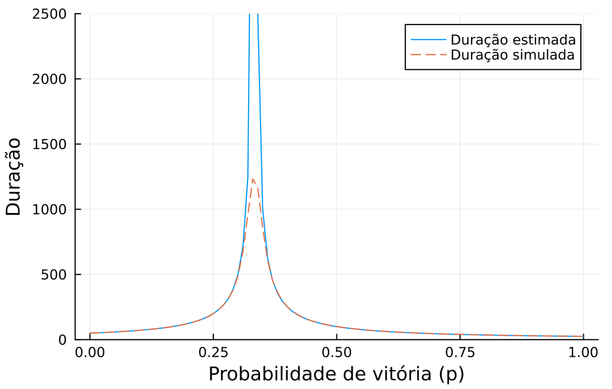

Figura 2: Comparação entre estimador simples e duração simulada para $a = 50$, $N = 100$, valor de perda $1 e de ganho $2, em função de $p$. Simulados com $10.000$ iterações de Monte Carlo.

Para jogos não unitários, o estimador também apresenta bom desempenho, como mostrado na Figura 2. Novamente, observa-se uma queda na precisão do estimador à medida que $\mathbb{E}(X)$ se aproxima de $0$.

Com esses resultados, validamos o estimador proposto na Definição 2 para passeios aleatórios em meio homogêneo, tanto unitários quanto não unitários. Dessa forma, partimos para a análise de passeios mais complexos.

# Referências

## Referências

ANDĚL, J.; HUDECOVÁ, Š. [Variance of the game duration in the gambler’s ruin problem](https://doi.org/10.1016/j.spl.2012.05.023). **Statistics & Probability Letters**, v. 82, n. 9, p. 1750–1754, 2012.

EDWARDS, A. W. F. [Pascal’s Problem: The ’Gambler’s Ruin’](https://doi.org/10.2307/1402732). **International Statistical Review / Revue Internationale de Statistique**, v. 51, n. 1, p. 73–79, 1983.

HARRISON, R. L. [Introduction To Monte Carlo Simulation](https://doi.org/10.1063/1.3295638). **AIP conference proceedings**, v. 1204, p. 17–21, 5 jan. 2010.

ISHIHARA, E. **Um Estimador para a Duração do Jogo da Ruína do Jogador**. São Paulo: Universidade de São Paulo, 2025.

RITTER, F. E. et al. [Determining the Number of Simulation Runs: Treating Simulations as Theories by Not Sampling Their Behavior](https://doi.org/10.1007/978-0-85729-883-6_5). Em: ROTHROCK, L.; NARAYANAN, S. (Eds.). **Human-in-the-Loop Simulations: Methods and Practice**. London: Springer, 2011. p. 97–116.

STERN, F. [Conditional Expectation of the Duration in the Classical Ruin Problem](https://doi.org/10.1080/0025570X.1975.11976486). **Mathematics Magazine**, v. 48, n. 4, p. 200–203, 1 set. 1975.